# Risk Factor Analysis

## Outcome Variable

**Outcome Variable:** stunted

## Predictor Variables

**Intervention Variable:** exclfeed6

**Adjustment Set:**

- arm
- sex
- W_mage
- meducyrs
- feducyrs
- hhwealth_quart
- hfoodsec
- W_mhtcm
- vagbrth
- W_gagebrth
- W_birthwt
- W_birthlen
- W_nrooms
- W_nchldlt5
- month
- brthmon
- W_parity
- impfloor
- impsan
- safeh20
- delta_W_mage
- delta_meducyrs
- delta_feducyrs
- delta_hhwealth_quart
- delta_hfoodsec
- delta_W_mhtcm
- delta_vagbrth
- delta_W_gagebrth
- delta_W_birthwt
- delta_W_birthlen
- delta_W_nrooms
- delta_W_nchldlt5
- delta_month
- delta_brthmon
- delta_W_parity
- delta_impfloor
- delta_impsan
- delta_safeh20

## Stratifying Variables

The analysis was stratified on these variable(s):

- agecat
- studyid
- country

## Data Summary

| agecat | studyid | country | exclfeed6 | stunted | n_cell | n |
| --- | --- | --- | --- | --- | --- | --- |
| Birth | ki0047075b-MAL-ED | BANGLADESH | 0 | 0 | 146 | 231 |
| Birth | ki0047075b-MAL-ED | BANGLADESH | 0 | 1 | 29 | 231 |
| Birth | ki0047075b-MAL-ED | BANGLADESH | 1 | 0 | 46 | 231 |
| Birth | ki0047075b-MAL-ED | BANGLADESH | 1 | 1 | 10 | 231 |
| Birth | ki0047075b-MAL-ED | BRAZIL | 0 | 0 | 148 | 175 |
| Birth | ki0047075b-MAL-ED | BRAZIL | 0 | 1 | 15 | 175 |
| Birth | ki0047075b-MAL-ED | BRAZIL | 1 | 0 | 10 | 175 |
| Birth | ki0047075b-MAL-ED | BRAZIL | 1 | 1 | 2 | 175 |
| Birth | ki0047075b-MAL-ED | INDIA | 0 | 0 | 157 | 190 |
| Birth | ki0047075b-MAL-ED | INDIA | 0 | 1 | 28 | 190 |
| Birth | ki0047075b-MAL-ED | INDIA | 1 | 0 | 2 | 190 |
| Birth | ki0047075b-MAL-ED | INDIA | 1 | 1 | 3 | 190 |
| Birth | ki0047075b-MAL-ED | NEPAL | 0 | 0 | 141 | 170 |
| Birth | ki0047075b-MAL-ED | NEPAL | 0 | 1 | 18 | 170 |
| Birth | ki0047075b-MAL-ED | NEPAL | 1 | 0 | 11 | 170 |
| Birth | ki0047075b-MAL-ED | NEPAL | 1 | 1 | 0 | 170 |
| Birth | ki0047075b-MAL-ED | PERU | 0 | 0 | 219 | 256 |
| Birth | ki0047075b-MAL-ED | PERU | 0 | 1 | 27 | 256 |
| Birth | ki0047075b-MAL-ED | PERU | 1 | 0 | 8 | 256 |
| Birth | ki0047075b-MAL-ED | PERU | 1 | 1 | 2 | 256 |
| Birth | ki0047075b-MAL-ED | SOUTH AFRICA | 0 | 0 | 189 | 211 |
| Birth | ki0047075b-MAL-ED | SOUTH AFRICA | 0 | 1 | 22 | 211 |
| Birth | ki0047075b-MAL-ED | SOUTH AFRICA | 1 | 0 | 0 | 211 |
| Birth | ki0047075b-MAL-ED | SOUTH AFRICA | 1 | 1 | 0 | 211 |
| Birth | ki0047075b-MAL-ED | TANZANIA, UNITED REPUBLIC OF | 0 | 0 | 102 | 119 |
| Birth | ki0047075b-MAL-ED | TANZANIA, UNITED REPUBLIC OF | 0 | 1 | 16 | 119 |
| Birth | ki0047075b-MAL-ED | TANZANIA, UNITED REPUBLIC OF | 1 | 0 | 1 | 119 |
| Birth | ki0047075b-MAL-ED | TANZANIA, UNITED REPUBLIC OF | 1 | 1 | 0 | 119 |
| Birth | ki1000108-CMC-V-BCS-2002 | INDIA | 0 | 0 | 0 | 7 |
| Birth | ki1000108-CMC-V-BCS-2002 | INDIA | 0 | 1 | 0 | 7 |

[output cut: 158 more lines]

The following strata were considered:

- agecat: 24 months, studyid: ki0047075b-MAL-ED, country: BANGLADESH
- agecat: 24 months, studyid: ki0047075b-MAL-ED, country: BRAZIL
- agecat: 24 months, studyid: ki0047075b-MAL-ED, country: INDIA
- agecat: 24 months, studyid: ki0047075b-MAL-ED, country: NEPAL
- agecat: 24 months, studyid: ki0047075b-MAL-ED, country: PERU
- agecat: 24 months, studyid: ki0047075b-MAL-ED, country: SOUTH AFRICA
- agecat: 24 months, studyid: ki0047075b-MAL-ED, country: TANZANIA, UNITED REPUBLIC OF
- agecat: 24 months, studyid: ki1000108-CMC-V-BCS-2002, country: INDIA
- agecat: 24 months, studyid: ki1000108-IRC, country: INDIA
- agecat: 24 months, studyid: ki1017093b-PROVIDE, country: BANGLADESH
- agecat: 24 months, studyid: ki1101329-Keneba, country: GAMBIA
- agecat: 24 months, studyid: ki1113344-GMS-Nepal, country: NEPAL
- agecat: 24 months, studyid: ki1148112-LCNI-5, country: MALAWI
- agecat: 24 months, studyid: kiGH5241-JiVitA-3, country: BANGLADESH
- agecat: 24 months, studyid: kiGH5241-JiVitA-4, country: BANGLADESH
- agecat: 6 months, studyid: ki0047075b-MAL-ED, country: BANGLADESH
- agecat: 6 months, studyid: ki0047075b-MAL-ED, country: BRAZIL
- agecat: 6 months, studyid: ki0047075b-MAL-ED, country: INDIA
- agecat: 6 months, studyid: ki0047075b-MAL-ED, country: NEPAL
- agecat: 6 months, studyid: ki0047075b-MAL-ED, country: PERU
- agecat: 6 months, studyid: ki0047075b-MAL-ED, country: SOUTH AFRICA
- agecat: 6 months, studyid: ki0047075b-MAL-ED, country: TANZANIA, UNITED REPUBLIC OF
- agecat: 6 months, studyid: ki1000108-CMC-V-BCS-2002, country: INDIA
- agecat: 6 months, studyid: ki1000108-IRC, country: INDIA
- agecat: 6 months, studyid: ki1000109-EE, country: PAKISTAN
- agecat: 6 months, studyid: ki1000304b-SAS-CompFeed, country: INDIA
- agecat: 6 months, studyid: ki1000304b-SAS-FoodSuppl, country: INDIA
- agecat: 6 months, studyid: ki1017093b-PROVIDE, country: BANGLADESH
- agecat: 6 months, studyid: ki1101329-Keneba, country: GAMBIA
- agecat: 6 months, studyid: ki1113344-GMS-Nepal, country: NEPAL
- agecat: 6 months, studyid: ki1148112-LCNI-5, country: MALAWI
- agecat: 6 months, studyid: kiGH5241-JiVitA-3, country: BANGLADESH
- agecat: 6 months, studyid: kiGH5241-JiVitA-4, country: BANGLADESH
- agecat: Birth, studyid: ki0047075b-MAL-ED, country: BANGLADESH
- agecat: Birth, studyid: ki0047075b-MAL-ED, country: BRAZIL
- agecat: Birth, studyid: ki0047075b-MAL-ED, country: INDIA
- agecat: Birth, studyid: ki0047075b-MAL-ED, country: NEPAL
- agecat: Birth, studyid: ki0047075b-MAL-ED, country: PERU
- agecat: Birth, studyid: ki0047075b-MAL-ED, country: SOUTH AFRICA
- agecat: Birth, studyid: ki0047075b-MAL-ED, country: TANZANIA, UNITED REPUBLIC OF
- agecat: Birth, studyid: ki1000108-CMC-V-BCS-2002, country: INDIA
- agecat: Birth, studyid: ki1000108-IRC, country: INDIA
- agecat: Birth, studyid: ki1000109-EE, country: PAKISTAN
- agecat: Birth, studyid: ki1000304b-SAS-CompFeed, country: INDIA
- agecat: Birth, studyid: ki1101329-Keneba, country: GAMBIA
- agecat: Birth, studyid: kiGH5241-JiVitA-3, country: BANGLADESH
- agecat: Birth, studyid: kiGH5241-JiVitA-4, country: BANGLADESH

### Dropped Strata

Some strata were dropped due to rare outcomes:

- agecat: Birth, studyid: ki0047075b-MAL-ED, country: BRAZIL
- agecat: Birth, studyid: ki0047075b-MAL-ED, country: INDIA
- agecat: Birth, studyid: ki0047075b-MAL-ED, country: NEPAL
- agecat: Birth, studyid: ki0047075b-MAL-ED, country: PERU
- agecat: Birth, studyid: ki0047075b-MAL-ED, country: SOUTH AFRICA
- agecat: Birth, studyid: ki0047075b-MAL-ED, country: TANZANIA, UNITED REPUBLIC OF
- agecat: Birth, studyid: ki1000108-CMC-V-BCS-2002, country: INDIA
- agecat: Birth, studyid: ki1000108-IRC, country: INDIA
- agecat: Birth, studyid: ki1000109-EE, country: PAKISTAN
- agecat: Birth, studyid: ki1000304b-SAS-CompFeed, country: INDIA
- agecat: 6 months, studyid: ki0047075b-MAL-ED, country: BRAZIL
- agecat: 6 months, studyid: ki0047075b-MAL-ED, country: INDIA
- agecat: 6 months, studyid: ki0047075b-MAL-ED, country: NEPAL
- agecat: 6 months, studyid: ki0047075b-MAL-ED, country: PERU
- agecat: 6 months, studyid: ki0047075b-MAL-ED, country: SOUTH AFRICA
- agecat: 6 months, studyid: ki0047075b-MAL-ED, country: TANZANIA, UNITED REPUBLIC OF
- agecat: 6 months, studyid: ki1000108-CMC-V-BCS-2002, country: INDIA
- agecat: 6 months, studyid: ki1000108-IRC, country: INDIA
- agecat: 6 months, studyid: ki1000304b-SAS-FoodSuppl, country: INDIA
- agecat: 24 months, studyid: ki0047075b-MAL-ED, country: BRAZIL
- agecat: 24 months, studyid: ki0047075b-MAL-ED, country: INDIA
- agecat: 24 months, studyid: ki0047075b-MAL-ED, country: NEPAL
- agecat: 24 months, studyid: ki0047075b-MAL-ED, country: PERU
- agecat: 24 months, studyid: ki0047075b-MAL-ED, country: SOUTH AFRICA
- agecat: 24 months, studyid: ki0047075b-MAL-ED, country: TANZANIA, UNITED REPUBLIC OF
- agecat: 24 months, studyid: ki1000108-CMC-V-BCS-2002, country: INDIA
- agecat: 24 months, studyid: ki1000108-IRC, country: INDIA

## Methods Detail

We’re interested in the causal parameters $E[Y_a]$ for all values of $a \in \mathcal{A}$. These parameters represent the mean outcome if, possibly contrary to fact, we intervened to set all units to have $A=a$. Under the randomization and positivity assumptions, these are identified by the statistical parameters $\psi_a=E_W[E_{Y|A,W}(Y|A=a,W)]$. In addition, we’re interested in the mean of $Y$, $E[Y]$ under no intervention (the observed mean). We will estimate these parameters by using SuperLearner to fit the relevant likelihood factors – $E_{Y|A,W}(Y|A=a,W)$ and $p(A=a|W)$, and then updating our likelihood fit using a joint TMLE.

For unadjusted analyses ($W=\{\}$), initial likelihoods were estimated using Lrnr_glm to estimate the simple $E(Y|A)$ and Lrnr_mean to estimate $p(A)$. For adjusted analyses, a small library containing Lrnr_glmnet, Lrnr_xgboost, and Lrnr_mean was used.

Having estimated these parameters, we will then use the delta method to estimate relative risks and attributable risks relative to a prespecified baseline level of $A$.

# Results Detail

## Results Plots

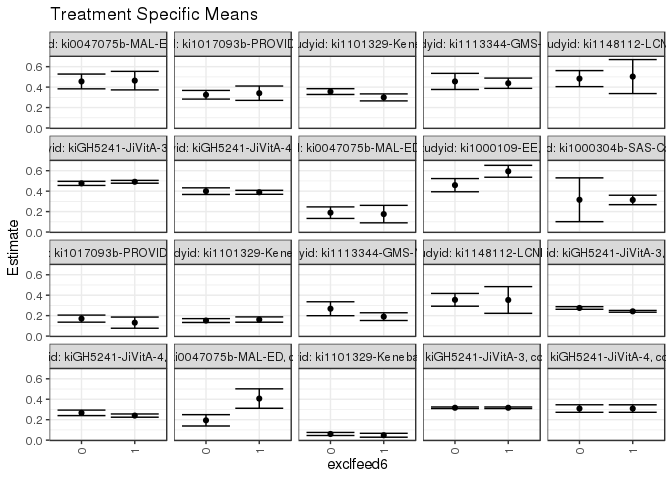

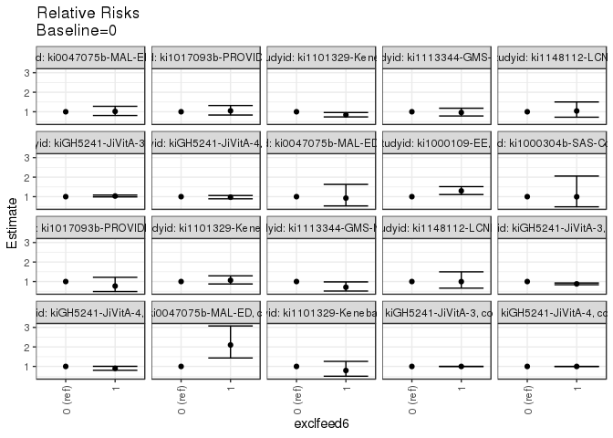

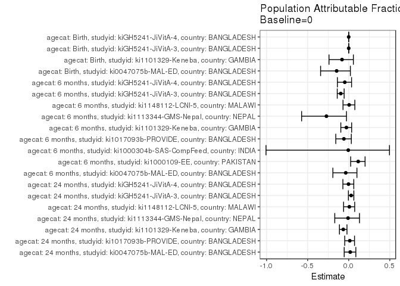

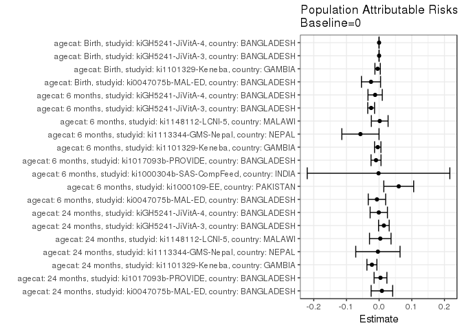

## Results Table

### Parameter: TSM

| agecat | studyid | country | intervention_level | baseline_level | estimate | ci_lower | ci_upper |
| --- | --- | --- | --- | --- | --- | --- | --- |
| Birth | ki0047075b-MAL-ED | BANGLADESH | 0 | NA | 0.1936246 | 0.1382319 | 0.2490173 |
| Birth | ki0047075b-MAL-ED | BANGLADESH | 1 | NA | 0.4065988 | 0.3115691 | 0.5016284 |
| Birth | ki1101329-Keneba | GAMBIA | 0 | NA | 0.0602136 | 0.0451641 | 0.0752632 |
| Birth | ki1101329-Keneba | GAMBIA | 1 | NA | 0.0477162 | 0.0287072 | 0.0667252 |
| Birth | kiGH5241-JiVitA-3 | BANGLADESH | 0 | NA | 0.3166358 | 0.3090268 | 0.3242447 |
| Birth | kiGH5241-JiVitA-3 | BANGLADESH | 1 | NA | 0.3166224 | 0.3090129 | 0.3242319 |
| Birth | kiGH5241-JiVitA-4 | BANGLADESH | 0 | NA | 0.3090917 | 0.2723210 | 0.3458625 |
| Birth | kiGH5241-JiVitA-4 | BANGLADESH | 1 | NA | 0.3089723 | 0.2722150 | 0.3457296 |
| 6 months | ki0047075b-MAL-ED | BANGLADESH | 0 | NA | 0.1895965 | 0.1332794 | 0.2459136 |
| 6 months | ki0047075b-MAL-ED | BANGLADESH | 1 | NA | 0.1754118 | 0.0899265 | 0.2608971 |
| 6 months | ki1000109-EE | PAKISTAN | 0 | NA | 0.4587465 | 0.3940999 | 0.5233931 |
| 6 months | ki1000109-EE | PAKISTAN | 1 | NA | 0.5944228 | 0.5362162 | 0.6526293 |
| 6 months | ki1000304b-SAS-CompFeed | INDIA | 0 | NA | 0.3157895 | 0.1014523 | 0.5301266 |
| 6 months | ki1000304b-SAS-CompFeed | INDIA | 1 | NA | 0.3139842 | 0.2679102 | 0.3600581 |
| 6 months | ki1017093b-PROVIDE | BANGLADESH | 0 | NA | 0.1706969 | 0.1362051 | 0.2051886 |
| 6 months | ki1017093b-PROVIDE | BANGLADESH | 1 | NA | 0.1313688 | 0.0767513 | 0.1859864 |
| 6 months | ki1101329-Keneba | GAMBIA | 0 | NA | 0.1519641 | 0.1332988 | 0.1706294 |
| 6 months | ki1101329-Keneba | GAMBIA | 1 | NA | 0.1616933 | 0.1357968 | 0.1875899 |
| 6 months | ki1113344-GMS-Nepal | NEPAL | 0 | NA | 0.2677796 | 0.1995946 | 0.3359646 |
| 6 months | ki1113344-GMS-Nepal | NEPAL | 1 | NA | 0.1902474 | 0.1522789 | 0.2282159 |
| 6 months | ki1148112-LCNI-5 | MALAWI | 0 | NA | 0.3547803 | 0.2924021 | 0.4171585 |
| 6 months | ki1148112-LCNI-5 | MALAWI | 1 | NA | 0.3532494 | 0.2225022 | 0.4839967 |
| 6 months | kiGH5241-JiVitA-3 | BANGLADESH | 0 | NA | 0.2751152 | 0.2622958 | 0.2879347 |
| 6 months | kiGH5241-JiVitA-3 | BANGLADESH | 1 | NA | 0.2421482 | 0.2334981 | 0.2507984 |
| 6 months | kiGH5241-JiVitA-4 | BANGLADESH | 0 | NA | 0.2667224 | 0.2399178 | 0.2935269 |
| 6 months | kiGH5241-JiVitA-4 | BANGLADESH | 1 | NA | 0.2400933 | 0.2243489 | 0.2558377 |
| 24 months | ki0047075b-MAL-ED | BANGLADESH | 0 | NA | 0.4555554 | 0.3833231 | 0.5277877 |
| 24 months | ki0047075b-MAL-ED | BANGLADESH | 1 | NA | 0.4636088 | 0.3730202 | 0.5541974 |
| 24 months | ki1017093b-PROVIDE | BANGLADESH | 0 | NA | 0.3250422 | 0.2825747 | 0.3675097 |
| 24 months | ki1017093b-PROVIDE | BANGLADESH | 1 | NA | 0.3406147 | 0.2704989 | 0.4107305 |
| 24 months | ki1101329-Keneba | GAMBIA | 0 | NA | 0.3564922 | 0.3282031 | 0.3847814 |
| 24 months | ki1101329-Keneba | GAMBIA | 1 | NA | 0.2995778 | 0.2653397 | 0.3338159 |
| 24 months | ki1113344-GMS-Nepal | NEPAL | 0 | NA | 0.4557649 | 0.3770326 | 0.5344972 |
| 24 months | ki1113344-GMS-Nepal | NEPAL | 1 | NA | 0.4381410 | 0.3878286 | 0.4884535 |
| 24 months | ki1148112-LCNI-5 | MALAWI | 0 | NA | 0.4831711 | 0.4046791 | 0.5616632 |
| 24 months | ki1148112-LCNI-5 | MALAWI | 1 | NA | 0.5031152 | 0.3367523 | 0.6694781 |
| 24 months | kiGH5241-JiVitA-3 | BANGLADESH | 0 | NA | 0.4761221 | 0.4560440 | 0.4962003 |
| 24 months | kiGH5241-JiVitA-3 | BANGLADESH | 1 | NA | 0.4917958 | 0.4777990 | 0.5057926 |
| 24 months | kiGH5241-JiVitA-4 | BANGLADESH | 0 | NA | 0.4001278 | 0.3676404 | 0.4326153 |
| 24 months | kiGH5241-JiVitA-4 | BANGLADESH | 1 | NA | 0.3887639 | 0.3694841 | 0.4080437 |

### Parameter: E(Y)

| agecat | studyid | country | intervention_level | baseline_level | estimate | ci_lower | ci_upper |
| --- | --- | --- | --- | --- | --- | --- | --- |
| Birth | ki0047075b-MAL-ED | BANGLADESH | NA | NA | 0.1688312 | 0.1204189 | 0.2172434 |
| Birth | ki1101329-Keneba | GAMBIA | NA | NA | 0.0556745 | 0.0436637 | 0.0676854 |
| Birth | kiGH5241-JiVitA-3 | BANGLADESH | NA | NA | 0.3166335 | 0.3090239 | 0.3242430 |
| Birth | kiGH5241-JiVitA-4 | BANGLADESH | NA | NA | 0.3089961 | 0.2722361 | 0.3457561 |
| 6 months | ki0047075b-MAL-ED | BANGLADESH | NA | NA | 0.1829787 | 0.1334386 | 0.2325189 |
| 6 months | ki1000109-EE | PAKISTAN | NA | NA | 0.5188172 | 0.4679751 | 0.5696593 |
| 6 months | ki1000304b-SAS-CompFeed | INDIA | NA | NA | 0.3140704 | 0.2712850 | 0.3568557 |
| 6 months | ki1017093b-PROVIDE | BANGLADESH | NA | NA | 0.1612350 | 0.1313580 | 0.1911120 |
| 6 months | ki1101329-Keneba | GAMBIA | NA | NA | 0.1477987 | 0.1318701 | 0.1637274 |
| 6 months | ki1113344-GMS-Nepal | NEPAL | NA | NA | 0.2106227 | 0.1763897 | 0.2448557 |
| 6 months | ki1148112-LCNI-5 | MALAWI | NA | NA | 0.3566176 | 0.2995882 | 0.4136471 |
| 6 months | kiGH5241-JiVitA-3 | BANGLADESH | NA | NA | 0.2508093 | 0.2426385 | 0.2589801 |
| 6 months | kiGH5241-JiVitA-4 | BANGLADESH | NA | NA | 0.2545198 | 0.2394884 | 0.2695513 |
| 24 months | ki0047075b-MAL-ED | BANGLADESH | NA | NA | 0.4641148 | 0.3963405 | 0.5318891 |
| 24 months | ki1017093b-PROVIDE | BANGLADESH | NA | NA | 0.3292894 | 0.2909105 | 0.3676684 |
| 24 months | ki1101329-Keneba | GAMBIA | NA | NA | 0.3344349 | 0.3106543 | 0.3582155 |
| 24 months | ki1113344-GMS-Nepal | NEPAL | NA | NA | 0.4520833 | 0.4075129 | 0.4966538 |
| 24 months | ki1148112-LCNI-5 | MALAWI | NA | NA | 0.4867725 | 0.4153250 | 0.5582200 |
| 24 months | kiGH5241-JiVitA-3 | BANGLADESH | NA | NA | 0.4907516 | 0.4775997 | 0.5039035 |
| 24 months | kiGH5241-JiVitA-4 | BANGLADESH | NA | NA | 0.3991375 | 0.3806098 | 0.4176653 |

### Parameter: RR

| agecat | studyid | country | intervention_level | baseline_level | estimate | ci_lower | ci_upper |
| --- | --- | --- | --- | --- | --- | --- | --- |
| Birth | ki0047075b-MAL-ED | BANGLADESH | 0 | 0 | 1.0000000 | 1.0000000 | 1.0000000 |
| Birth | ki0047075b-MAL-ED | BANGLADESH | 1 | 0 | 2.0999335 | 1.4343723 | 3.0743210 |
| Birth | ki1101329-Keneba | GAMBIA | 0 | 0 | 1.0000000 | 1.0000000 | 1.0000000 |
| Birth | ki1101329-Keneba | GAMBIA | 1 | 0 | 0.7924485 | 0.4986964 | 1.2592324 |
| Birth | kiGH5241-JiVitA-3 | BANGLADESH | 0 | 0 | 1.0000000 | 1.0000000 | 1.0000000 |
| Birth | kiGH5241-JiVitA-3 | BANGLADESH | 1 | 0 | 0.9999578 | 0.9999234 | 0.9999921 |
| Birth | kiGH5241-JiVitA-4 | BANGLADESH | 0 | 0 | 1.0000000 | 1.0000000 | 1.0000000 |
| Birth | kiGH5241-JiVitA-4 | BANGLADESH | 1 | 0 | 0.9996138 | 0.9987856 | 1.0004426 |
| 6 months | ki0047075b-MAL-ED | BANGLADESH | 0 | 0 | 1.0000000 | 1.0000000 | 1.0000000 |
| 6 months | ki0047075b-MAL-ED | BANGLADESH | 1 | 0 | 0.9251846 | 0.5258325 | 1.6278312 |
| 6 months | ki1000109-EE | PAKISTAN | 0 | 0 | 1.0000000 | 1.0000000 | 1.0000000 |
| 6 months | ki1000109-EE | PAKISTAN | 1 | 0 | 1.2957543 | 1.1081952 | 1.5150573 |
| 6 months | ki1000304b-SAS-CompFeed | INDIA | 0 | 0 | 1.0000000 | 1.0000000 | 1.0000000 |
| 6 months | ki1000304b-SAS-CompFeed | INDIA | 1 | 0 | 0.9942832 | 0.4810773 | 2.0549693 |
| 6 months | ki1017093b-PROVIDE | BANGLADESH | 0 | 0 | 1.0000000 | 1.0000000 | 1.0000000 |
| 6 months | ki1017093b-PROVIDE | BANGLADESH | 1 | 0 | 0.7696030 | 0.4867845 | 1.2167372 |
| 6 months | ki1101329-Keneba | GAMBIA | 0 | 0 | 1.0000000 | 1.0000000 | 1.0000000 |
| 6 months | ki1101329-Keneba | GAMBIA | 1 | 0 | 1.0640233 | 0.8760796 | 1.2922863 |
| 6 months | ki1113344-GMS-Nepal | NEPAL | 0 | 0 | 1.0000000 | 1.0000000 | 1.0000000 |
| 6 months | ki1113344-GMS-Nepal | NEPAL | 1 | 0 | 0.7104627 | 0.5141699 | 0.9816935 |
| 6 months | ki1148112-LCNI-5 | MALAWI | 0 | 0 | 1.0000000 | 1.0000000 | 1.0000000 |
| 6 months | ki1148112-LCNI-5 | MALAWI | 1 | 0 | 0.9956851 | 0.6623055 | 1.4968753 |
| 6 months | kiGH5241-JiVitA-3 | BANGLADESH | 0 | 0 | 1.0000000 | 1.0000000 | 1.0000000 |
| 6 months | kiGH5241-JiVitA-3 | BANGLADESH | 1 | 0 | 0.8801702 | 0.8367442 | 0.9258499 |
| 6 months | kiGH5241-JiVitA-4 | BANGLADESH | 0 | 0 | 1.0000000 | 1.0000000 | 1.0000000 |
| 6 months | kiGH5241-JiVitA-4 | BANGLADESH | 1 | 0 | 0.9001618 | 0.8054923 | 1.0059578 |
| 24 months | ki0047075b-MAL-ED | BANGLADESH | 0 | 0 | 1.0000000 | 1.0000000 | 1.0000000 |
| 24 months | ki0047075b-MAL-ED | BANGLADESH | 1 | 0 | 1.0176781 | 0.8094711 | 1.2794389 |
| 24 months | ki1017093b-PROVIDE | BANGLADESH | 0 | 0 | 1.0000000 | 1.0000000 | 1.0000000 |
| 24 months | ki1017093b-PROVIDE | BANGLADESH | 1 | 0 | 1.0479092 | 0.8324116 | 1.3191956 |
| 24 months | ki1101329-Keneba | GAMBIA | 0 | 0 | 1.0000000 | 1.0000000 | 1.0000000 |
| 24 months | ki1101329-Keneba | GAMBIA | 1 | 0 | 0.8403488 | 0.7350549 | 0.9607256 |
| 24 months | ki1113344-GMS-Nepal | NEPAL | 0 | 0 | 1.0000000 | 1.0000000 | 1.0000000 |
| 24 months | ki1113344-GMS-Nepal | NEPAL | 1 | 0 | 0.9613313 | 0.7827841 | 1.1806039 |
| 24 months | ki1148112-LCNI-5 | MALAWI | 0 | 0 | 1.0000000 | 1.0000000 | 1.0000000 |
| 24 months | ki1148112-LCNI-5 | MALAWI | 1 | 0 | 1.0412775 | 0.7221495 | 1.5014326 |
| 24 months | kiGH5241-JiVitA-3 | BANGLADESH | 0 | 0 | 1.0000000 | 1.0000000 | 1.0000000 |
| 24 months | kiGH5241-JiVitA-3 | BANGLADESH | 1 | 0 | 1.0329193 | 0.9883866 | 1.0794586 |
| 24 months | kiGH5241-JiVitA-4 | BANGLADESH | 0 | 0 | 1.0000000 | 1.0000000 | 1.0000000 |
| 24 months | kiGH5241-JiVitA-4 | BANGLADESH | 1 | 0 | 0.9715993 | 0.8913870 | 1.0590296 |

### Parameter: PAR

| agecat | studyid | country | intervention_level | baseline_level | estimate | ci_lower | ci_upper |
| --- | --- | --- | --- | --- | --- | --- | --- |
| Birth | ki0047075b-MAL-ED | BANGLADESH | 0 | NA | -0.0247934 | -0.0540979 | 0.0045111 |
| Birth | ki1101329-Keneba | GAMBIA | 0 | NA | -0.0045391 | -0.0127830 | 0.0037048 |
| Birth | kiGH5241-JiVitA-3 | BANGLADESH | 0 | NA | -0.0000023 | -0.0000106 | 0.0000060 |
| Birth | kiGH5241-JiVitA-4 | BANGLADESH | 0 | NA | -0.0000956 | -0.0003007 | 0.0001095 |
| 6 months | ki0047075b-MAL-ED | BANGLADESH | 0 | NA | -0.0066178 | -0.0332632 | 0.0200276 |
| 6 months | ki1000109-EE | PAKISTAN | 0 | NA | 0.0600707 | 0.0143516 | 0.1057897 |
| 6 months | ki1000304b-SAS-CompFeed | INDIA | 0 | NA | -0.0017191 | -0.2199177 | 0.2164795 |
| 6 months | ki1017093b-PROVIDE | BANGLADESH | 0 | NA | -0.0094619 | -0.0247127 | 0.0057889 |
| 6 months | ki1101329-Keneba | GAMBIA | 0 | NA | -0.0041653 | -0.0138945 | 0.0055639 |
| 6 months | ki1113344-GMS-Nepal | NEPAL | 0 | NA | -0.0571569 | -0.1140735 | -0.0002403 |
| 6 months | ki1148112-LCNI-5 | MALAWI | 0 | NA | 0.0018374 | -0.0237976 | 0.0274723 |
| 6 months | kiGH5241-JiVitA-3 | BANGLADESH | 0 | NA | -0.0243060 | -0.0347405 | -0.0138714 |
| 6 months | kiGH5241-JiVitA-4 | BANGLADESH | 0 | NA | -0.0122025 | -0.0341038 | 0.0096988 |
| 24 months | ki0047075b-MAL-ED | BANGLADESH | 0 | NA | 0.0085594 | -0.0243881 | 0.0415069 |
| 24 months | ki1017093b-PROVIDE | BANGLADESH | 0 | NA | 0.0042472 | -0.0153647 | 0.0238591 |
| 24 months | ki1101329-Keneba | GAMBIA | 0 | NA | -0.0220573 | -0.0373056 | -0.0068091 |
| 24 months | ki1113344-GMS-Nepal | NEPAL | 0 | NA | -0.0036815 | -0.0714629 | 0.0640999 |
| 24 months | ki1148112-LCNI-5 | MALAWI | 0 | NA | 0.0036014 | -0.0292973 | 0.0365001 |
| 24 months | kiGH5241-JiVitA-3 | BANGLADESH | 0 | NA | 0.0146295 | -0.0016272 | 0.0308861 |
| 24 months | kiGH5241-JiVitA-4 | BANGLADESH | 0 | NA | -0.0009903 | -0.0274791 | 0.0254985 |

### Parameter: PAF

| agecat | studyid | country | intervention_level | baseline_level | estimate | ci_lower | ci_upper |
| --- | --- | --- | --- | --- | --- | --- | --- |
| Birth | ki0047075b-MAL-ED | BANGLADESH | 0 | NA | -0.1468533 | -0.3423708 | 0.0201869 |
| Birth | ki1101329-Keneba | GAMBIA | 0 | NA | -0.0815296 | -0.2399628 | 0.0566602 |
| Birth | kiGH5241-JiVitA-3 | BANGLADESH | 0 | NA | -0.0000072 | -0.0000334 | 0.0000189 |
| Birth | kiGH5241-JiVitA-4 | BANGLADESH | 0 | NA | -0.0003094 | -0.0009726 | 0.0003532 |
| 6 months | ki0047075b-MAL-ED | BANGLADESH | 0 | NA | -0.0361669 | -0.1928634 | 0.0999457 |
| 6 months | ki1000109-EE | PAKISTAN | 0 | NA | 0.1157839 | 0.0236531 | 0.1992210 |
| 6 months | ki1000304b-SAS-CompFeed | INDIA | 0 | NA | -0.0054737 | -1.0068383 | 0.4962338 |
| 6 months | ki1017093b-PROVIDE | BANGLADESH | 0 | NA | -0.0586838 | -0.1574678 | 0.0316695 |
| 6 months | ki1101329-Keneba | GAMBIA | 0 | NA | -0.0281825 | -0.0962374 | 0.0356476 |
| 6 months | ki1113344-GMS-Nepal | NEPAL | 0 | NA | -0.2713711 | -0.5735889 | -0.0271961 |
| 6 months | ki1148112-LCNI-5 | MALAWI | 0 | NA | 0.0051522 | -0.0693916 | 0.0744997 |
| 6 months | kiGH5241-JiVitA-3 | BANGLADESH | 0 | NA | -0.0969102 | -0.1396533 | -0.0557703 |
| 6 months | kiGH5241-JiVitA-4 | BANGLADESH | 0 | NA | -0.0479433 | -0.1376149 | 0.0346600 |
| 24 months | ki0047075b-MAL-ED | BANGLADESH | 0 | NA | 0.0184424 | -0.0549331 | 0.0867143 |
| 24 months | ki1017093b-PROVIDE | BANGLADESH | 0 | NA | 0.0128981 | -0.0484563 | 0.0706622 |
| 24 months | ki1101329-Keneba | GAMBIA | 0 | NA | -0.0659540 | -0.1127732 | -0.0211047 |
| 24 months | ki1113344-GMS-Nepal | NEPAL | 0 | NA | -0.0081435 | -0.1698588 | 0.1312172 |
| 24 months | ki1148112-LCNI-5 | MALAWI | 0 | NA | 0.0073985 | -0.0625438 | 0.0727368 |
| 24 months | kiGH5241-JiVitA-3 | BANGLADESH | 0 | NA | 0.0298103 | -0.0038317 | 0.0623248 |
| 24 months | kiGH5241-JiVitA-4 | BANGLADESH | 0 | NA | -0.0024812 | -0.0710910 | 0.0617338 |